# Problem Set 04: Linear Regression

Isaac Allen

Last compiled: September 15, 2020

# 1 Background

For this problem set you will first run through an example of a simple linear regression, answering a few questions on the way. Then you will work through a regression analysis independently. Knit this file...and you can read through all the instructions.

We will look at some demographic data from the `fivethirtyeight` package recorded for 48 voting areas in the US states just after the 2016 presidential election. We will investigate what variables within those regions might be tied to the percentage of US voters that supported Donald Trump, and in turn, which variables might be useful to predict Trump support in other regions (i.e. to a wider US population).

# 2 Setup

## 2.1 Load Packages

We will read the data in with the `readr` package, explore the data using the `dplyr` package and visualize the data using the `ggplot2` package. The `moderndive` package includes some nice functions to show regression model outputs.

```r
library(dplyr)
library(ggplot2)
library(readr)
library(moderndive)
```

## 2.2 The Data

The following uses the function `read_csv()` to read a `*.CSV` file of the data from where it is published on the web.

```r
trump <- read_csv("https://docs.google.com/spreadsheets/d/e/2PACX-1vT8qHdvTPaRc62hU94ShBcSh04HP3c11b6XZIPMiUDGuwPtifpP7QhHdSHS2YgTRMRTgfUmBYq-L3ZT/pub?gid=1217616678&single=true&output=csv")
```

Take a moment to look at the data in the viewer or by using `glimpse()`.

```r
glimpse(trump)
```

```
Rows: 48
Columns: 4
$ hs_ed         <dbl> 90.4, 80.6, 91.0, 89.0, 89.0, 84.7, 89.7, 86.4, 82.8, 8…
$ poverty       <dbl> 7, 9, 10, 8, 6, 10, 9, 7, 10, 8, 6, 10, 8, 7, 7, 12, 5,…
$ non_white     <dbl> 81, 61, 6, 27, 50, 42, 31, 37, 62, 28, 30, 26, 37, 44, …
$ trump_support <dbl> 30, 33, 33, 34, 35, 37, 38, 39, 40, 40, 41, 41, 42, 42,…
```

The explanatory variables include:

- `hs_ed` - the percentage of the adults in the region with a high school education.
- `poverty`- the percentage of the "white" households in the region in poverty.
- `non_white`- the percentage of humans in a region that identify as a person of color.

The outcome variable `trump_support` is the percentage of votes for Trump in 2016 in each region.

Observe that all percentages are expressed as values between 0 and 100, and not 0 and 1.

# 3 An Example/Demo

## 3.1 Visualization

We will start by investigating the relationship between white poverty levels and support for Trump.

We'll do this by creating a scatterplot with `trump_support` as the outcome variable on the y-axis and `poverty` as the explanatory variable on the x-axis. Note the use of the `geom_smooth()` function, that tells R to add a regression line. While the points do scatter/vary around the blue regression line, of all possible lines we can draw in this point of clouds, the blue line is the "best-fitting" line in that in minimizes the sum of the squared residuals.

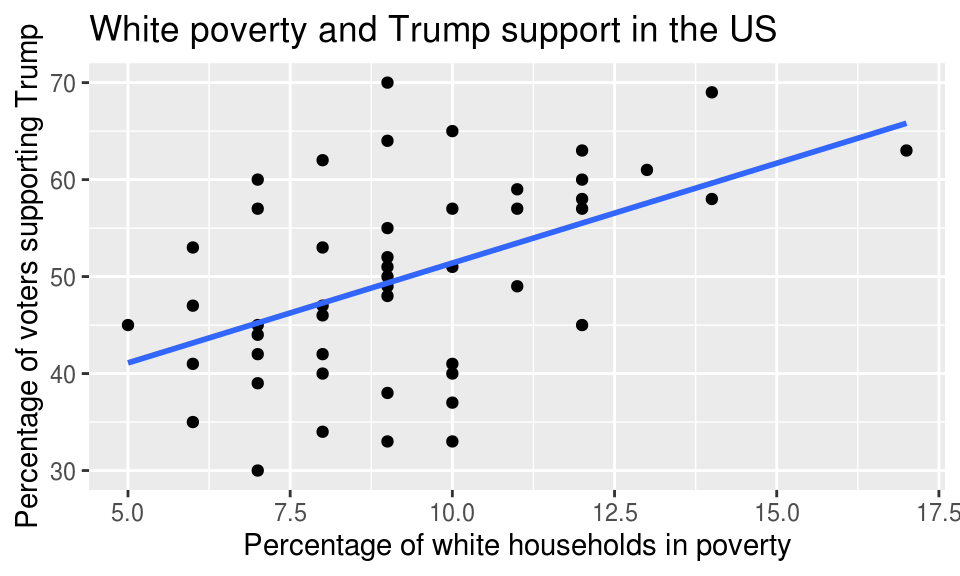

```r
ggplot(data = trump, aes(y = trump_support, x = poverty)) +
  geom_point() +
  geom_smooth(method = "lm", se = FALSE) +
  labs(x = "Percentage of white households in poverty",
       y = "Percentage of voters supporting Trump",
       title = "White poverty and Trump support in the US")
```

1. Does the relationship appear to be positive or negative? Does it look to be reasonably linear?

The relationship between the percentage of voters supporting Trump vs. the percentage of white households in poverty appears to be positive and looks reasonably linear.

## 3.2 The Correlation Coefficient (r)

We can numerically quantify the strength of the linear relationship between the two variables with the correlation coefficient. The following tells R to `summarize()` the correlation coefficient between the numerical variables `poverty` and `trump_support`. Note that the correlation coefficient only exists for pairs of numerical variables.

```r
trump %>%
  summarise(r = cor(trump_support, poverty))
```

| r |
| --- |
| 0.4864114 |

## 3.3 Running a Linear Regression Model

In R we can fit a linear regression model (a regression line), like so:

```r
poverty_mod <- lm(trump_support ~ poverty, data = trump)
```

Note that:

- the function `lm()` is short for "linear model"
- the first argument is a *formula* in the form `y ~ x` or in other words `outcome variable ~ explantory variable`.
- the second argument is the data frame in which the outcome and explanatory variables can be found.
- we **SAVED THE MODEL RESULTS** as an object called `poverty_mod`

This object `poverty_mod` contains all of the information we need about the linear model that was just fit and we'll be accessing this information again later.

## 3.4 Get the Regression Table

The `get_regression_table()` function from the `moderndive` package will output a regression table. Let's focus on the value in the second column: an estimate for 1) an intercept, and 2) a slope for the `poverty` variable. We'll revisit what the other columns mean in a future problem set.

```r
get_regression_table(poverty_mod)
```

| term | estimate | std_error | statistic | p_value | lower_ci | upper_ci |
| --- | --- | --- | --- | --- | --- | --- |
| intercept | 30.806 | 5.223 | 5.898 | 0 | 20.293 | 41.320 |
| poverty | 2.059 | 0.545 | 3.776 | 0 | 0.961 | 3.157 |

We can interpret the `intercept` and `poverty` slope like so:

- When the poverty level is 0, the predicted average Trump support is 30.81%
- For every increase in poverty level of 1 percentage point, there is an **associated increase** in Trump support of 2.059 percentage points.

Revisiting the plot from earlier, we can see that the best-fit line hits the y axis at 30.8064 (if we extend it). This is the intercept...the y value at which poverty = 0 (note, a value that is sadly not close to the range of values for "percentage of white households in poverty").

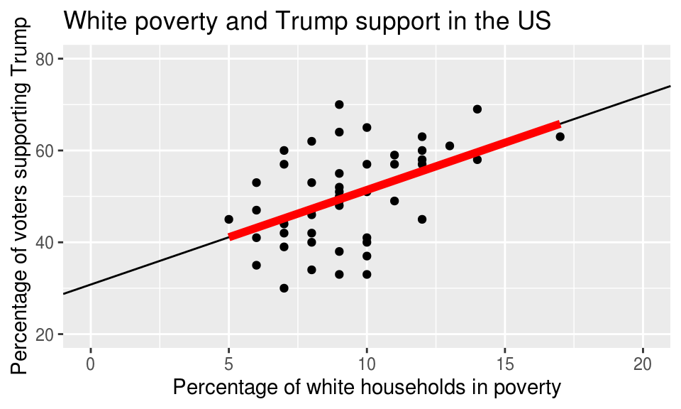

2. We found a positive correlation coefficient. Is it reasonable for us to conclude that social policies that increase white poverty will **cause** an increase in Trump support? Explain why or why not?

It is certainly unreasonable for us to make any conclusions regarding the causation of this positive correllation. Firstly, there isn't sufficient data for us to draw any sort of predictive judgement, and secondly, even if we were to compare a plethora of data simultaneously that suggests this, it would be unreasonable for use to make an absolute conclusion based on such relevant correlations supporting its assertion; correlation isn't necesarrily causation. Using thorough multiple regression, it may however be reasonable to suspect, not conclude, this idea.

## 3.5 Making Predictions

Based on the R output of our model, the following is our least squares regression line for the linear model:

$\widehat{trump\_support} = 30.806 + 2.059 \times poverty$

We can use the line from our graph of the `trump_support` versus `poverty` relationship to **visually** make predictions...for instance at 15% white poverty, the line shows a value of just over 60% Trump support.

To get a **more accurate** prediction, we could actually plug 15% into the regression equation like so:

```r
y_hat = 30.8064 + 2.0591 * 15
y_hat
```

```
[1] 61.6929
```

3. What percent of Trump support would you expect at a value of 6% white poverty?

```r
 q_3 <- get_regression_table(poverty_mod)
 y_hat_2 <- round(q_3[2]$estimate[1], 2) + round(q_3[2]$estimate[2], 2) * 6
```

At a value of 6% white poverty, one could expect to see 43.17% Trump support based on the relationship given in the .csv we're using in this problem set.

4. Do you think it is a good idea to predict Trump support at 85% white poverty, based on this regression equation? Explain your reasoning.

It's most certainly a bad idea to predict Trump support at 85% white poverty. This percentage is absolutely unrealistic and the data provided supports that claim. To get an idea of this, based off the provided fitted equation, if there was 85% white poverty, the percentage of Trump support would be 205.91%! We can't have more than 100% support! There's no data points available past 20% white poverty. Doing so would absolutley be an extrapolation.

## 3.6 Residuals

Recall that model residuals are the difference between the **observed values in your data set** and the **values predicted by the line**:

$\text{residual} = y - \hat{y}$

For instance, below, one data point is highlighted in blue...the residual is the difference between the y value of the **data point** (here 69), and the y value **predicted** by the line (roughly 59). Here the residual is roughly 10 ($69 - 59 = 10$). The regression equation has under-estimated Trump support, compared to this data point.

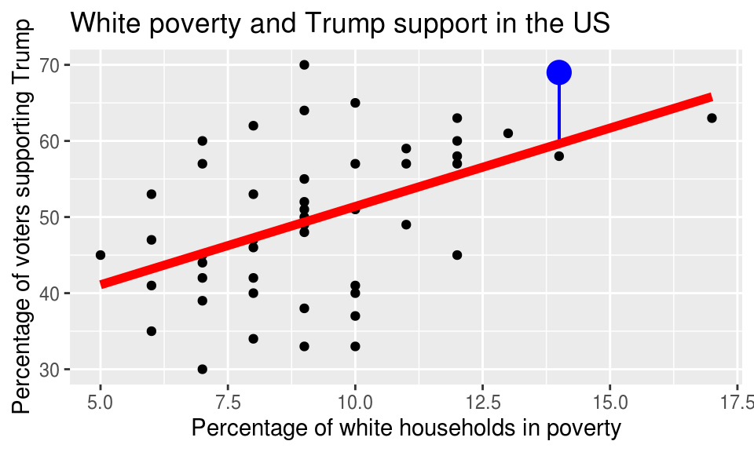

The function `get_regression_points()` provides the **fitted** also known as **predicted** value for every data point, and the **residual** for every data point. The first row in the output is the first data point...you see that Trump support was 30%, white poverty was 7%, the regression equation predicted 45.22% Trump support, and the residual was $-15.22 = (30 - 45.22)$.

```r
results <- get_regression_points(poverty_mod)
head(results)
```

| ID | trump_support | poverty | trump_support_hat | residual |
| --- | --- | --- | --- | --- |
| 1 | 30 | 7 | 45.220 | -15.220 |
| 2 | 33 | 9 | 49.338 | -16.338 |
| 3 | 33 | 10 | 51.397 | -18.397 |
| 4 | 34 | 8 | 47.279 | -13.279 |
| 5 | 35 | 6 | 43.161 | -8.161 |
| 6 | 37 | 10 | 51.397 | -14.397 |

## 3.7 Put your Skills to Practice Independently!

Use the same `trump` data set for the following questions:

5. Generate a scatterplot with a best-fitting line with `non_white` as the explanatory variable, and `trump_support` as the response. Be sure to include an informative title and axis labels for your plot. This will help contextualize it.

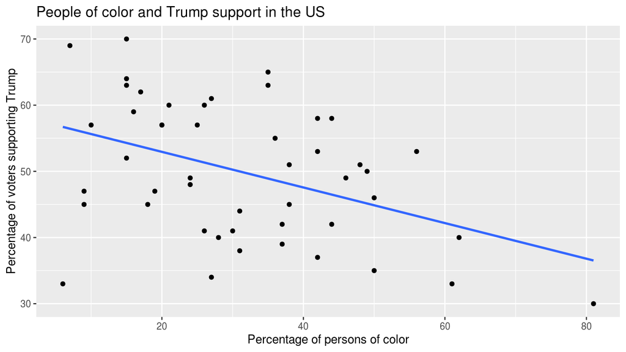

```r
ggplot(data = trump, aes(x = non_white, y = trump_support)) +
  geom_point() +
  geom_smooth(method = lm, se = FALSE) +
  labs(x = "Percentage of persons of color",
       y = "Percentage of voters supporting Trump",
       title = "People of color and Trump support in the US")
```

6. Do you expect the correlation coefficient (for `non_white` and `trump_support`) to be positive or negative? Write code chunk testing your prediction (it is OK if your expectation was wrong!).

I expect this correlation coefficient to be negative, since the trendline has an apparent negative slope.

```r
trump %>%
  summarize(r = cor(trump_support, non_white))
```

| r |
| --- |
| -0.4250604 |

7. Run a linear regression using `non_white` as the **explanatory** variable, and `trump_support` as the **outcome** variable. Store your linear model in the object `nw_mod`. Use the `get_regression_table()` function on `nw_mod` and interpret the intercept and slope estimates.

```r
nw_mod <- lm(trump_support ~ non_white, data = trump)
get_regression_table(nw_mod)
```

| term | estimate | std_error | statistic | p_value | lower_ci | upper_ci |
| --- | --- | --- | --- | --- | --- | --- |
| intercept | 58.328 | 2.976 | 19.601 | 0.000 | 52.338 | 64.318 |
| non_white | -0.269 | 0.084 | -3.185 | 0.003 | -0.439 | -0.099 |

Based off the regression table for nw_mod, when people of color is at 0% the data shows an estimated 58.33% Trump support with a -0.27% change in Trump support for every 1% increase in people of color.

8. Make a numerical prediction for the level of trump support for a region that has 70% of humans that identify as a person of color. In other words, use **math** not a visual prediction.

```r
y_hat_3 <- round(nw_mod[1]$coefficients[1], 2) + round(nw_mod[1]$coefficients[2], 2) * 70
```

An estimate of 39.43% Trump support is predicted from the fitted Trump support vs. Non-white equation at 70% Non-whites.

9. Based on the evidence you have so far (scatterplots and correlation coefficients), which of the explanatory variables we have considered (`non_white` or `poverty`) seems to be a better explanatory variable of Trump support? Explain.

Personally, none of the explanatory variables we've looked at in this problem set seem to be "better" than another in terms of explaining Trump support. There are 48 points in each set so that's not really an issue. I would need more context about the background behind the support of Trump to rule either of these out as being the lesser of the two and even still it's only 2 sets of data we're referring to!

10. If Representative Ocasio-Cortez saw the regression line (`nw_mod`) and not the actual data:
- What would her prediction of Trump support be for a region in which 61% of the people identify as non-white?

```r
nw_mod <- lm(trump_support ~ non_white, data = trump)
non_wh_61 <- get_regression_points(nw_mod) %>%
  filter(non_white == 61)
non_wh_61
```

| ID | trump_support | non_white | trump_support_hat | residual |
| --- | --- | --- | --- | --- |
| 2 | 33 | 61 | 41.912 | -8.912 |

```r
 out <- if(non_wh_61$residual[1] < 0)
  {
    sprintf("she'd be overestimating support by %4.2f%%.",
            round((non_wh_61$residual[1] * -1), 2))
  } else if(non_wh_61$residual[1] == 0)
    {
      paste("she'd be accurate in her prediction.")
    } else
      {
        sprintf("she'd be underestimating support by %4.2f%%.",
                round(non_wh_61$residual[1], 2))
      }
```

Her prediction would be 41.91 %.

- Would her prediction be an overestimate or an underestimate (compared to the observed data), and by how much?

Considering the data point at 61% non-white is 33% support and its respective fitted y value at 41.91%  
she'd be overestimating support by 8.91%.

- In other words, what is the residual for this prediction?

The residual for this prediction is -8.91%.